# Chelicerate GRAMPA

```r
knitr::opts_chunk$set(echo = TRUE, warning = FALSE, message = FALSE)

library(ggplot2)
library(cowplot)
#library(ggbeeswarm)
library(dplyr)
library(kableExtra)
#library(tidyr)
library(ggtree)
#library(phytools)
#library(phangorn)
#library(reshape2)
library(ggExtra)
#library(ggrepel)
#library(vroom)
#library(ggdist)
#library(stringr)
#library(ggsignif)
library(here)
source("../lib/design.r")
source("../lib/get_tree_info.r")
#source("C:/Users/grt814/bin/core/corelib/design.r")
#source("C:/Users/grt814/bin/core/get_tree_info.r")

#htmltools::includeHTML("../html-chunks/rmd_nav.html")
```

< Back to project

```r
save_tree_fig = F
# Meta options. Comment tree_type when running form generator

cds_apro_full_file = here("data", "grampa", "cds-apro-full-grampa.txt")
cds_apro_spider_file = here("data", "grampa", "cds-apro-h1-5-grampa.txt")
cds_apro_hc_file = here("data", "grampa", "cds-apro-h1-7-grampa.txt")
cds_apro_hcs_file = here("data", "grampa", "cds-apro-h1-5-7-grampa.txt")
ball_full_file = here("data", "grampa", "ballesteros-full-grampa.txt")
trad_full_file = here("data", "grampa", "traditional-full-grampa.txt")

cds_apro_r70_full_file = here("data", "grampa", "cds-apro-r70-full-grampa.txt")
cds_apro_r70_spider_file = here("data", "grampa", "cds-apro-r70-h1-5-grampa.txt")
cds_apro_r70_hc_file = here("data", "grampa", "cds-apro-r70-h1-7-grampa.txt")
cds_apro_r70_hcs_file = here("data", "grampa", "cds-apro-r70-h1-5-7-grampa.txt")
ball_r70_full_file = here("data", "grampa", "ballesteros-r70-full-grampa.txt")
trad_r70_full_file = here("data", "grampa", "traditional-r70-full-grampa.txt")

cds_apro_r90_full_file = here("data", "grampa", "cds-apro-r90-full-grampa.txt")
cds_apro_r90_spider_file = here("data", "grampa", "cds-apro-r90-h1-5-grampa.txt")
cds_apro_r90_hc_file = here("data", "grampa", "cds-apro-r90-h1-7-grampa.txt")
cds_apro_r90_hcs_file = here("data", "grampa", "cds-apro-r90-h1-5-7-grampa.txt")
ball_r90_full_file = here("data", "grampa", "ballesteros-r90-full-grampa.txt")
trad_r90_full_file = here("data", "grampa", "traditional-r90-full-grampa.txt")

genome_file = here("data", "chelicerate_genomes-gwct.csv")

summary_file = here("data", "gene-trees.csv")

genome_data = read.csv(genome_file, header=T)
genome_data = subset(genome_data, Include=="Y")

spec_abbrs = select(genome_data, S.name, Abbr)
names(spec_abbrs)[2] = "label"

combined_scores = data.frame()
```

Here we run GRAMPA using multiple species tree hypotheses to find the scenario that best fits the gene tree topologies.

# 1 ASTRAL-pro species tree

```r
## Full search

### Input species tree and score distribution

cur_data = read.csv(cds_apro_full_file, comment.char="#", header=T, sep="\t")
# Read the GRAMPA results

cur_data$Tree.string = paste(cur_data$Tree.string, ";", sep="")
# Add the semi-colons to the trees so they can be read by R

cur_data = cur_data[order(cur_data$Total.score), ]
# Re-order the rows by score

cur_data$rank = seq_along(cur_data[,1])
# Add a column for rank (just row number in re-ordered rows)

#cds_apro_r70_full$rank = as.numeric(as.character(cds_apro_r70_full$rank))
# Convert ranks to numeric

####################

st_string = cur_data$Tree.string[cur_data$Tree=="ST"]
# Extract the species tree string

st = read.tree(text=st_string)
# Read the species tree

famcol = corecol(pal="wilke", numcol=1, offset=2)
famoffset = 4
# Order labels

cur_st_fig = ggtree(st, size=0.8, ladderize=T) +#, aes(color=full_data$Family)) +
  xlim(0, 20) +
  geom_tiplab(size=4) +
  #scale_color_manual(name='Include?', values=c("N"=corecol(pal="wilke", numcol=1,offset=1), "Y"=corecol(numcol=1, offset=1))) +
  #geom_text(aes(label=node), hjust=-.3, vjust=-.3, color="#ff6db6") +

  geom_cladelabel(node=22, label="Araneae", align=T, color=corecol(numcol=1, offset=2), offset=famoffset) +
  geom_cladelabel(node=7, label="Scorpiones", align=T, color=corecol(numcol=1), offset=famoffset) +
  geom_cladelabel(node=27, label="Xiphosura", align=T, color=corecol(numcol=1, offset=4), offset=famoffset) +
  geom_cladelabel(node=28, label="Acariformes", align=T, color=corecol(numcol=1, offset=7), offset=famoffset) +
  geom_cladelabel(node=29, label="Parasitiformes", align=T, color=corecol(numcol=1, offset=1, pal="trek"), offset=famoffset) +
  geom_cladelabel(node=15, label="Diptera", align=T, color="#333333", offset=famoffset) +
  geom_cladelabel(node=16, label="Lepidoptera", align=T, color="#333333", offset=famoffset) +
  ggtitle(paste("CDS A-pro full search tree\n(", nrow(cur_data), " trees)", sep=""))

#print(cur_st_fig)
# Plot tree

####################

cur_scores_fig = ggplot(cur_data, aes(x=rank, y=Total.score)) +
  geom_point(size=2, color=corecol(pal="wilke", numcol=1), alpha=0.33) +
  scale_x_continuous(limits=c(-10,max(cur_data$rank)+10)) +
  xlab("Rank") +
  ylab("GRAMPA score") +
  bartheme()
#print(cds_apro_r70_full_scores_fig)
# Plot scores

####################

cur_figs = plot_grid(cur_st_fig, cur_scores_fig, rel_widths=c(0.8,1))
#print(cur_figs)
# Combine tree and score figs
```

```r
### Lowest scoring trees

cur_data_lowest = head(cur_data, 6)
# Get the lowest scoring trees

tree_fig_list = list()
# A list to store tree figures

for(i in 1:nrow(cur_data_lowest)){
  tree = read.tree(text=cur_data_lowest[i,]$Tree.string)
  # Read the current tree

  tree_fig = ggtree(tree, size=0.5, ladderize=T) +
  xlim(0, 14) +
    geom_tiplab(size=2.5) +
  ggtitle(paste(cur_data_lowest[i,]$Tree, " (", cur_data_lowest[i,]$Total.score, ")", sep=""))
  # Plot the current tree

  tree_fig_list[[i]] = tree_fig
  # Add the tree to the tree list
}

tree_figs = plot_grid(plotlist=tree_fig_list, ncol=3)
#print(tree_figs)
# Combine and render figs

cur_data_lowest$run = "CDS A-pro full"
combined_scores = rbind(combined_scores, cur_data_lowest)
```

## 1.1 Full search, bootstrap rearrange 90

### 1.1.1 Input species tree and score distribution

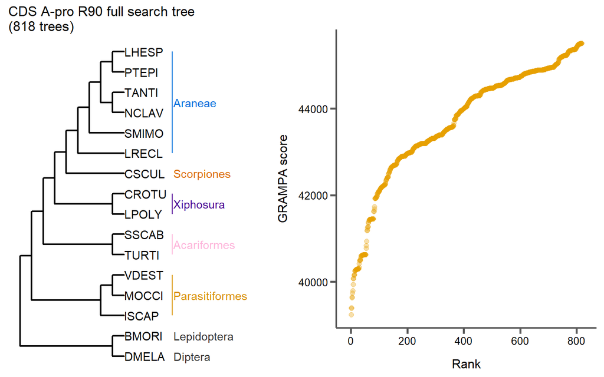

```r
cur_data = read.csv(cds_apro_r90_full_file, comment.char="#", header=T, sep="\t")
# Read the GRAMPA results

cur_data$Tree.string = paste(cur_data$Tree.string, ";", sep="")
# Add the semi-colons to the trees so they can be read by R

cur_data = cur_data[order(cur_data$Total.score), ]
# Re-order the rows by score

cur_data$rank = seq_along(cur_data[,1])
# Add a column for rank (just row number in re-ordered rows)

#cds_apro_r70_full$rank = as.numeric(as.character(cds_apro_r70_full$rank))
# Convert ranks to numeric

####################

st_string = cur_data$Tree.string[cur_data$Tree=="ST"]
# Extract the species tree string

st = read.tree(text=st_string)
# Read the species tree

famcol = corecol(pal="wilke", numcol=1, offset=2)
famoffset = 4
# Order labels

cur_st_fig = ggtree(st, size=0.8, ladderize=T) +#, aes(color=full_data$Family)) +
  xlim(0, 20) +
  geom_tiplab(size=4) +
  #scale_color_manual(name='Include?', values=c("N"=corecol(pal="wilke", numcol=1,offset=1), "Y"=corecol(numcol=1, offset=1))) +
  #geom_text(aes(label=node), hjust=-.3, vjust=-.3, color="#ff6db6") +

  geom_cladelabel(node=22, label="Araneae", align=T, color=corecol(numcol=1, offset=2), offset=famoffset) +
  geom_cladelabel(node=7, label="Scorpiones", align=T, color=corecol(numcol=1), offset=famoffset) +
  geom_cladelabel(node=27, label="Xiphosura", align=T, color=corecol(numcol=1, offset=4), offset=famoffset) +
  geom_cladelabel(node=28, label="Acariformes", align=T, color=corecol(numcol=1, offset=7), offset=famoffset) +
  geom_cladelabel(node=29, label="Parasitiformes", align=T, color=corecol(numcol=1, offset=1, pal="trek"), offset=famoffset) +
  geom_cladelabel(node=15, label="Diptera", align=T, color="#333333", offset=famoffset) +
  geom_cladelabel(node=16, label="Lepidoptera", align=T, color="#333333", offset=famoffset) +
  ggtitle(paste("CDS A-pro R90 full search tree\n(", nrow(cur_data), " trees)", sep=""))

#print(cur_st_fig)
# Plot tree

####################

cur_scores_fig = ggplot(cur_data, aes(x=rank, y=Total.score)) +
  geom_point(size=2, color=corecol(pal="wilke", numcol=1), alpha=0.33) +
  scale_x_continuous(limits=c(-10,max(cur_data$rank)+10)) +
  xlab("Rank") +
  ylab("GRAMPA score") +
  bartheme()
#print(cds_apro_r70_full_scores_fig)
# Plot scores

####################

cur_figs = plot_grid(cur_st_fig, cur_scores_fig, rel_widths=c(0.8,1))
print(cur_figs)
```

```r
# Combine tree and score figs
```

### 1.1.2 Lowest scoring trees

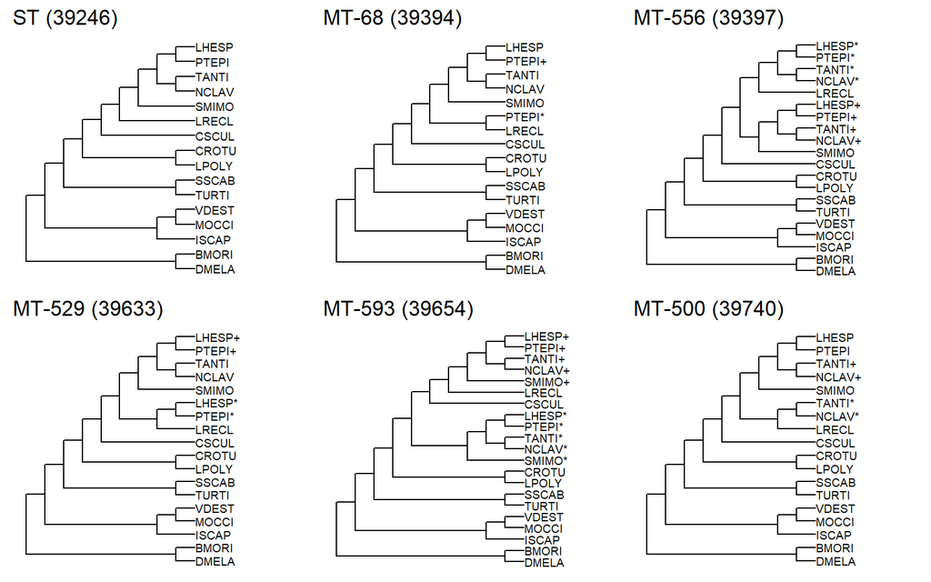

```r
cur_data_lowest = head(cur_data, 6)
# Get the lowest scoring trees

tree_fig_list = list()
# A list to store tree figures

for(i in 1:nrow(cur_data_lowest)){
  tree = read.tree(text=cur_data_lowest[i,]$Tree.string)
  # Read the current tree

  tree_fig = ggtree(tree, size=0.5, ladderize=T) +
  xlim(0, 14) +
    geom_tiplab(size=2.5) +
  ggtitle(paste(cur_data_lowest[i,]$Tree, " (", cur_data_lowest[i,]$Total.score, ")", sep=""))
  # Plot the current tree

  tree_fig_list[[i]] = tree_fig
  # Add the tree to the tree list
}

tree_figs = plot_grid(plotlist=tree_fig_list, ncol=3)
print(tree_figs)
```

```r
# Combine and render figs

cur_data_lowest$run = "CDS A-pro R90 full"
combined_scores = rbind(combined_scores, cur_data_lowest)
```

## 1.2 H1 spider (5) and horseshoe crab (7) search, bootstrap rearrange 90

### 1.2.1 Input species tree and score distribution

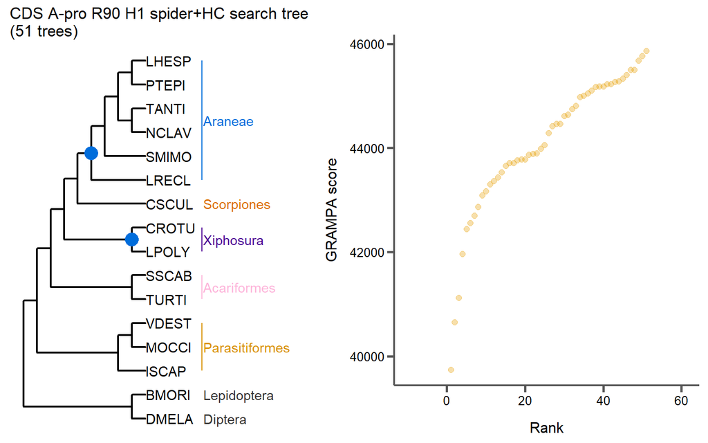

```r
cur_data = read.csv(cds_apro_r90_hcs_file, comment.char="#", header=T, sep="\t")
# Read the GRAMPA results

cur_data$Tree.string = paste(cur_data$Tree.string, ";", sep="")
# Add the semi-colons to the trees so they can be read by R

cur_data = cur_data[order(cur_data$Total.score), ]
# Re-order the rows by score

cur_data$rank = seq_along(cur_data[,1])
# Add a column for rank (just row number in re-ordered rows)

#cds_apro_r70_full$rank = as.numeric(as.character(cds_apro_r70_full$rank))
# Convert ranks to numeric

####################

st_string = cur_data$Tree.string[cur_data$Tree=="ST"]
# Extract the species tree string

st = read.tree(text=st_string)
# Read the species tree

famcol = corecol(pal="wilke", numcol=1, offset=2)
famoffset = 4
# Order labels

cur_st_fig = ggtree(st, size=0.8, ladderize=T) +
  xlim(0, 20) +
  geom_tiplab(size=4) +
  #geom_text(aes(label=node), hjust=-.3, vjust=-.3, color="#ff6db6") +

  geom_point2(aes(subset=node==22), color=corecol(numcol=1, offset=2), size=5) +
  geom_point2(aes(subset=node==27), color=corecol(numcol=1, offset=2), size=5) +

  geom_cladelabel(node=22, label="Araneae", align=T, color=corecol(numcol=1, offset=2), offset=famoffset) +
  geom_cladelabel(node=7, label="Scorpiones", align=T, color=corecol(numcol=1), offset=famoffset) +
  geom_cladelabel(node=27, label="Xiphosura", align=T, color=corecol(numcol=1, offset=4), offset=famoffset) +
  geom_cladelabel(node=28, label="Acariformes", align=T, color=corecol(numcol=1, offset=7), offset=famoffset) +
  geom_cladelabel(node=29, label="Parasitiformes", align=T, color=corecol(numcol=1, offset=1, pal="trek"), offset=famoffset) +
  geom_cladelabel(node=15, label="Diptera", align=T, color="#333333", offset=famoffset) +
  geom_cladelabel(node=16, label="Lepidoptera", align=T, color="#333333", offset=famoffset) +

  ggtitle(paste("CDS A-pro R90 H1 spider+HC search tree\n(", nrow(cur_data), " trees)", sep=""))

#print(cur_st_fig)
# Plot tree

####################

cur_scores_fig = ggplot(cur_data, aes(x=rank, y=Total.score)) +
  geom_point(size=2, color=corecol(pal="wilke", numcol=1), alpha=0.33) +
  scale_x_continuous(limits=c(-10,max(cur_data$rank)+10)) +
  xlab("Rank") +
  ylab("GRAMPA score") +
  bartheme()
#print(cds_apro_r70_full_scores_fig)
# Plot scores

####################

cur_figs = plot_grid(cur_st_fig, cur_scores_fig, rel_widths=c(0.8,1))
print(cur_figs)
```

```r
# Combine tree and score figs
```

### 1.2.2 Lowest scoring trees

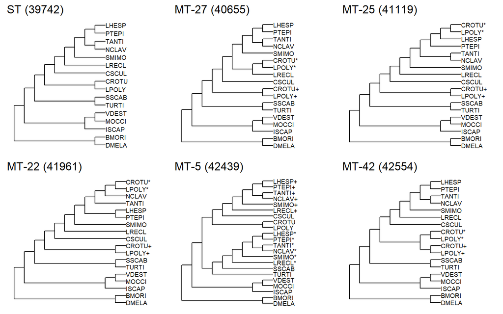

```r
cur_data_lowest = head(cur_data, 6)
# Get the lowest scoring trees

tree_fig_list = list()
# A list to store tree figures

for(i in 1:nrow(cur_data_lowest)){
  tree = read.tree(text=cur_data_lowest[i,]$Tree.string)
  # Read the current tree

  tree_fig = ggtree(tree, size=0.5, ladderize=T) +
  xlim(0, 14) +
    geom_tiplab(size=2.5) +
  ggtitle(paste(cur_data_lowest[i,]$Tree, " (", cur_data_lowest[i,]$Total.score, ")", sep=""))
  # Plot the current tree

  tree_fig_list[[i]] = tree_fig
  # Add the tree to the tree list
}

tree_figs = plot_grid(plotlist=tree_fig_list, ncol=3)
print(tree_figs)
```

```r
# Combine and render figs

# cur_data_lowest$run = "CDS A-pro R70 full"
# combined_scores = rbind(combined_scores, cur_data_lowest)

#############################################################
```

# 2 Monophyletic Arachnid species tree

```r
## Full search

### Input species tree and score distribution

cur_data = read.csv(trad_full_file, comment.char="#", header=T, sep="\t")
# Read the GRAMPA results

cur_data$Tree.string = paste(cur_data$Tree.string, ";", sep="")
# Add the semi-colons to the trees so they can be read by R

cur_data = cur_data[order(cur_data$Total.score), ]
# Re-order the rows by score

cur_data$rank = seq_along(cur_data[,1])
# Add a column for rank (just row number in re-ordered rows)

#cds_apro_r70_full$rank = as.numeric(as.character(cds_apro_r70_full$rank))
# Convert ranks to numeric

####################

st_string = cur_data$Tree.string[cur_data$Tree=="ST"]
# Extract the species tree string

st = read.tree(text=st_string)
# Read the species tree

famcol = corecol(pal="wilke", numcol=1, offset=2)
famoffset = 4
# Order labels

cur_st_fig = ggtree(st, size=0.8, ladderize=T) +
  xlim(0, 20) +
  geom_tiplab(size=4) +
  #geom_text(aes(label=node), hjust=-.3, vjust=-.3, color="#ff6db6") +

  #geom_point2(aes(subset=node==27), color=corecol(numcol=1, offset=2), size=5) +

  geom_cladelabel(node=22, label="Araneae", align=T, color=corecol(numcol=1, offset=2), offset=famoffset) +
  geom_cladelabel(node=7, label="Scorpiones", align=T, color=corecol(numcol=1), offset=famoffset) +
  geom_cladelabel(node=30, label="Xiphosura", align=T, color=corecol(numcol=1, offset=4), offset=famoffset) +
  geom_cladelabel(node=29, label="Acariformes", align=T, color=corecol(numcol=1, offset=7), offset=famoffset) +
  geom_cladelabel(node=27, label="Parasitiformes", align=T, color=corecol(numcol=1, offset=1, pal="trek"), offset=famoffset) +
  geom_cladelabel(node=15, label="Diptera", align=T, color="#333333", offset=famoffset) +
  geom_cladelabel(node=16, label="Lepidoptera", align=T, color="#333333", offset=famoffset) +

  ggtitle(paste("Monophyletic Arachnid search tree\n(", nrow(cur_data), " trees)", sep=""))

#print(cur_st_fig)
# Plot tree

####################

cur_scores_fig = ggplot(cur_data, aes(x=rank, y=Total.score)) +
  geom_point(size=2, color=corecol(pal="wilke", numcol=1), alpha=0.33) +
  scale_x_continuous(limits=c(-1,max(cur_data$rank)+1)) +
  xlab("Rank") +
  ylab("GRAMPA score") +
  bartheme()
#print(cds_apro_r70_full_scores_fig)
# Plot scores

####################

cur_figs = plot_grid(cur_st_fig, cur_scores_fig, rel_widths=c(0.8,1))
#print(cur_figs)
# Combine tree and score figs
```

```r
## Lowest scoring trees

cur_data_lowest = head(cur_data, 6)
# Get the lowest scoring trees

tree_fig_list = list()
# A list to store tree figures

for(i in 1:nrow(cur_data_lowest)){
  tree = read.tree(text=cur_data_lowest[i,]$Tree.string)
  # Read the current tree

  tree_fig = ggtree(tree, size=0.5, ladderize=T) +
  xlim(0, 14) +
    geom_tiplab(size=2.5) +
  ggtitle(paste(cur_data_lowest[i,]$Tree, " (", cur_data_lowest[i,]$Total.score, ")", sep=""))
  # Plot the current tree

  tree_fig_list[[i]] = tree_fig
  # Add the tree to the tree list
}

tree_figs = plot_grid(plotlist=tree_fig_list, ncol=3)
#print(tree_figs)
# Combine and render figs

cur_data_lowest$run = "Monophyletic Arachnid full"
combined_scores = rbind(combined_scores, cur_data_lowest)
```

## 2.1 Full search, bootstrap rearrange 90

### 2.1.1 Input species tree and score distribution

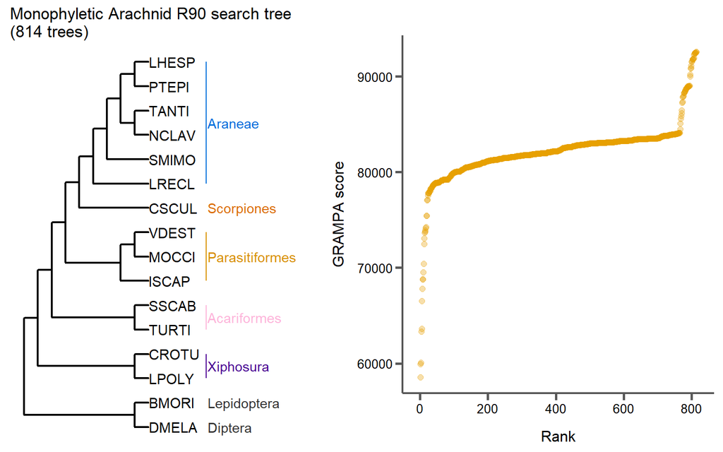

```r
cur_data = read.csv(trad_r90_full_file, comment.char="#", header=T, sep="\t")
# Read the GRAMPA results

cur_data$Tree.string = paste(cur_data$Tree.string, ";", sep="")
# Add the semi-colons to the trees so they can be read by R

cur_data = cur_data[order(cur_data$Total.score), ]
# Re-order the rows by score

cur_data$rank = seq_along(cur_data[,1])
# Add a column for rank (just row number in re-ordered rows)

#cds_apro_r70_full$rank = as.numeric(as.character(cds_apro_r70_full$rank))
# Convert ranks to numeric

####################

st_string = cur_data$Tree.string[cur_data$Tree=="ST"]
# Extract the species tree string

st = read.tree(text=st_string)
# Read the species tree

famcol = corecol(pal="wilke", numcol=1, offset=2)
famoffset = 4
# Order labels

cur_st_fig = ggtree(st, size=0.8, ladderize=T) +
  xlim(0, 20) +
  geom_tiplab(size=4) +
  #geom_text(aes(label=node), hjust=-.3, vjust=-.3, color="#ff6db6") +
  #geom_point2(aes(subset=node==27), color=corecol(numcol=1, offset=2), size=5) +

  geom_cladelabel(node=22, label="Araneae", align=T, color=corecol(numcol=1, offset=2), offset=famoffset) +
  geom_cladelabel(node=7, label="Scorpiones", align=T, color=corecol(numcol=1), offset=famoffset) +
  geom_cladelabel(node=30, label="Xiphosura", align=T, color=corecol(numcol=1, offset=4), offset=famoffset) +
  geom_cladelabel(node=29, label="Acariformes", align=T, color=corecol(numcol=1, offset=7), offset=famoffset) +
  geom_cladelabel(node=27, label="Parasitiformes", align=T, color=corecol(numcol=1, offset=1, pal="trek"), offset=famoffset) +
  geom_cladelabel(node=15, label="Diptera", align=T, color="#333333", offset=famoffset) +
  geom_cladelabel(node=16, label="Lepidoptera", align=T, color="#333333", offset=famoffset) +

  ggtitle(paste("Monophyletic Arachnid R90 search tree\n(", nrow(cur_data), " trees)", sep=""))

#print(cur_st_fig)
# Plot tree

####################

cur_scores_fig = ggplot(cur_data, aes(x=rank, y=Total.score)) +
  geom_point(size=2, color=corecol(pal="wilke", numcol=1), alpha=0.33) +
  scale_x_continuous(limits=c(-10,max(cur_data$rank)+10)) +
  xlab("Rank") +
  ylab("GRAMPA score") +
  bartheme()
#print(cds_apro_r70_full_scores_fig)
# Plot scores

####################

cur_figs = plot_grid(cur_st_fig, cur_scores_fig, rel_widths=c(0.8,1))
print(cur_figs)
```

```r
# Combine tree and score figs
```

## 2.2 Lowest scoring trees

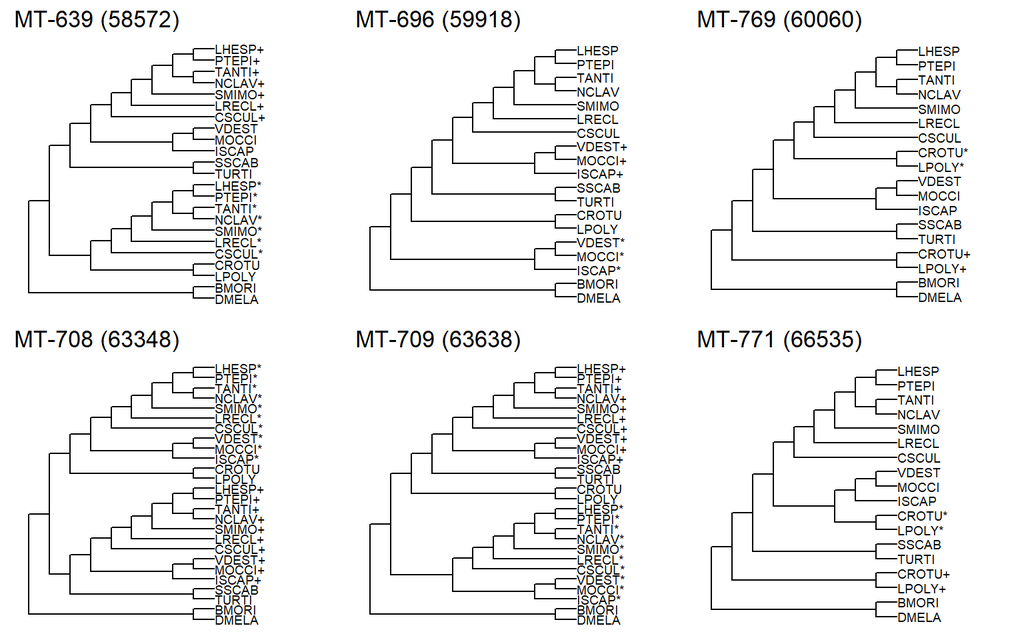

```r
cur_data_lowest = head(cur_data, 6)
# Get the lowest scoring trees

tree_fig_list = list()
# A list to store tree figures

for(i in 1:nrow(cur_data_lowest)){
  tree = read.tree(text=cur_data_lowest[i,]$Tree.string)
  # Read the current tree

  tree_fig = ggtree(tree, size=0.5, ladderize=T) +
  xlim(0, 14) +
    geom_tiplab(size=2.5) +
  ggtitle(paste(cur_data_lowest[i,]$Tree, " (", cur_data_lowest[i,]$Total.score, ")", sep=""))
  # Plot the current tree

  tree_fig_list[[i]] = tree_fig
  # Add the tree to the tree list
}

tree_figs = plot_grid(plotlist=tree_fig_list, ncol=3)
print(tree_figs)
```

```r
# Combine and render figs

cur_data_lowest$run = "Monophyletic Arachnid R90 full"
combined_scores = rbind(combined_scores, cur_data_lowest)
```

# 3 Ballesteros species tree

```r
## Full search

### Input species tree and score distribution

cur_data = read.csv(ball_full_file, comment.char="#", header=T, sep="\t")
# Read the GRAMPA results

cur_data$Tree.string = paste(cur_data$Tree.string, ";", sep="")
# Add the semi-colons to the trees so they can be read by R

cur_data = cur_data[order(cur_data$Total.score), ]
# Re-order the rows by score

cur_data$rank = seq_along(cur_data[,1])
# Add a column for rank (just row number in re-ordered rows)

#cds_apro_r70_full$rank = as.numeric(as.character(cds_apro_r70_full$rank))
# Convert ranks to numeric

####################

st_string = cur_data$Tree.string[cur_data$Tree=="ST"]
# Extract the species tree string

st = read.tree(text=st_string)
# Read the species tree

famcol = corecol(pal="wilke", numcol=1, offset=2)
famoffset = 4
# Order labels

cur_st_fig = ggtree(st, size=0.8, ladderize=T) +
  xlim(0, 20) +
  geom_tiplab(size=4) +
  #geom_text(aes(label=node), hjust=-.3, vjust=-.3, color="#ff6db6") +

  #geom_point2(aes(subset=node==27), color=corecol(numcol=1, offset=2), size=5) +

  geom_cladelabel(node=22, label="Araneae", align=T, color=corecol(numcol=1, offset=2), offset=famoffset) +
  geom_cladelabel(node=7, label="Scorpiones", align=T, color=corecol(numcol=1), offset=famoffset) +
  geom_cladelabel(node=27, label="Xiphosura", align=T, color=corecol(numcol=1, offset=4), offset=famoffset) +
  geom_cladelabel(node=30, label="Acariformes", align=T, color=corecol(numcol=1, offset=7), offset=famoffset) +
  geom_cladelabel(node=29, label="Parasitiformes", align=T, color=corecol(numcol=1, offset=1, pal="trek"), offset=famoffset) +
  geom_cladelabel(node=15, label="Diptera", align=T, color="#333333", offset=famoffset) +
  geom_cladelabel(node=16, label="Lepidoptera", align=T, color="#333333", offset=famoffset) +

  ggtitle(paste("Ballesteros full search tree\n(", nrow(cur_data), " trees)", sep=""))

#print(cur_st_fig)
# Plot tree

####################

cur_scores_fig = ggplot(cur_data, aes(x=rank, y=Total.score)) +
  geom_point(size=2, color=corecol(pal="wilke", numcol=1), alpha=0.33) +
  scale_x_continuous(limits=c(-1,max(cur_data$rank)+1)) +
  xlab("Rank") +
  ylab("GRAMPA score") +
  bartheme()
#print(cds_apro_r70_full_scores_fig)
# Plot scores

####################

cur_figs = plot_grid(cur_st_fig, cur_scores_fig, rel_widths=c(0.8,1))
#print(cur_figs)
# Combine tree and score figs
```

```r
### Lowest scoring trees

cur_data_lowest = head(cur_data, 6)
# Get the lowest scoring trees

tree_fig_list = list()
# A list to store tree figures

for(i in 1:nrow(cur_data_lowest)){
  tree = read.tree(text=cur_data_lowest[i,]$Tree.string)
  # Read the current tree

  tree_fig = ggtree(tree, size=0.5, ladderize=T) +
  xlim(0, 14) +
    geom_tiplab(size=2.5) +
  ggtitle(paste(cur_data_lowest[i,]$Tree, " (", cur_data_lowest[i,]$Total.score, ")", sep=""))
  # Plot the current tree

  tree_fig_list[[i]] = tree_fig
  # Add the tree to the tree list
}

tree_figs = plot_grid(plotlist=tree_fig_list, ncol=3)
#print(tree_figs)
# Combine and render figs

cur_data_lowest$run = "Ballesteros full"
combined_scores = rbind(combined_scores, cur_data_lowest)
```

## 3.1 Full search, bootstrap rearrange 90

### 3.1.1 Input species tree and score distribution

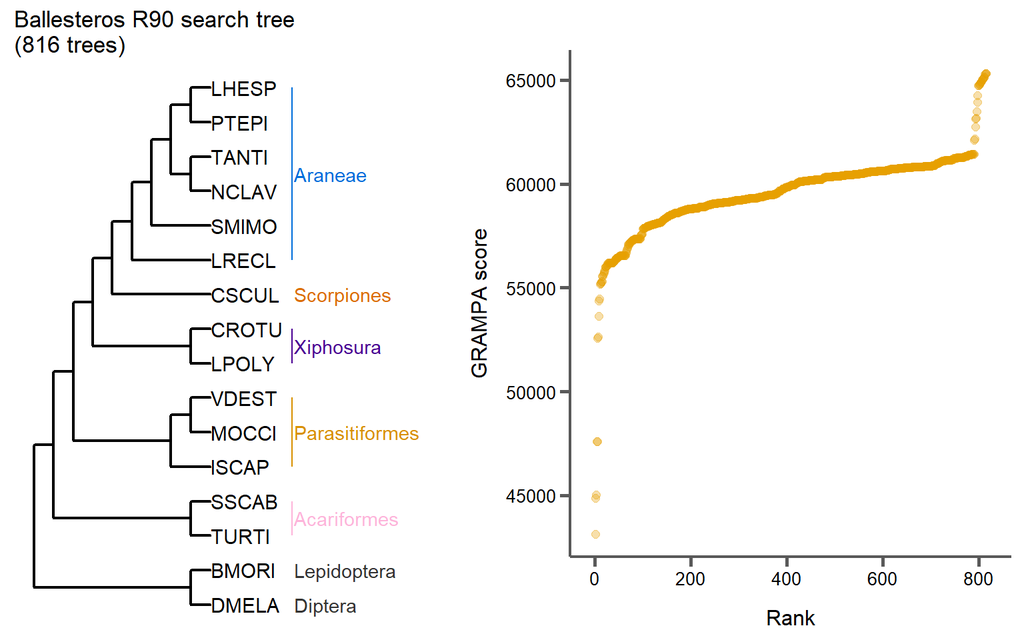

```r
cur_data = read.csv(ball_r90_full_file, comment.char="#", header=T, sep="\t")
# Read the GRAMPA results

cur_data$Tree.string = paste(cur_data$Tree.string, ";", sep="")
# Add the semi-colons to the trees so they can be read by R

cur_data = cur_data[order(cur_data$Total.score), ]
# Re-order the rows by score

cur_data$rank = seq_along(cur_data[,1])
# Add a column for rank (just row number in re-ordered rows)

#cds_apro_r70_full$rank = as.numeric(as.character(cds_apro_r70_full$rank))
# Convert ranks to numeric

####################

st_string = cur_data$Tree.string[cur_data$Tree=="ST"]
# Extract the species tree string

st = read.tree(text=st_string)
# Read the species tree

famcol = corecol(pal="wilke", numcol=1, offset=2)
famoffset = 4
# Order labels

cur_st_fig = ggtree(st, size=0.8, ladderize=T) +
  xlim(0, 20) +
  geom_tiplab(size=4) +
  #geom_text(aes(label=node), hjust=-.3, vjust=-.3, color="#ff6db6") +

  geom_cladelabel(node=22, label="Araneae", align=T, color=corecol(numcol=1, offset=2), offset=famoffset) +
  geom_cladelabel(node=7, label="Scorpiones", align=T, color=corecol(numcol=1), offset=famoffset) +
  geom_cladelabel(node=27, label="Xiphosura", align=T, color=corecol(numcol=1, offset=4), offset=famoffset) +
  geom_cladelabel(node=30, label="Acariformes", align=T, color=corecol(numcol=1, offset=7), offset=famoffset) +
  geom_cladelabel(node=28, label="Parasitiformes", align=T, color=corecol(numcol=1, offset=1, pal="trek"), offset=famoffset) +
  geom_cladelabel(node=15, label="Diptera", align=T, color="#333333", offset=famoffset) +
  geom_cladelabel(node=16, label="Lepidoptera", align=T, color="#333333", offset=famoffset) +

  ggtitle(paste("Ballesteros R90 search tree\n(", nrow(cur_data), " trees)", sep=""))

#print(cur_st_fig)
# Plot tree

####################

cur_scores_fig = ggplot(cur_data, aes(x=rank, y=Total.score)) +
  geom_point(size=2, color=corecol(pal="wilke", numcol=1), alpha=0.33) +
  scale_x_continuous(limits=c(-10,max(cur_data$rank)+10)) +
  xlab("Rank") +
  ylab("GRAMPA score") +
  bartheme()
#print(cds_apro_r70_full_scores_fig)
# Plot scores

####################

cur_figs = plot_grid(cur_st_fig, cur_scores_fig, rel_widths=c(0.8,1))
print(cur_figs)
```

```r
# Combine tree and score figs
```

### 3.1.2 Lowest scoring trees

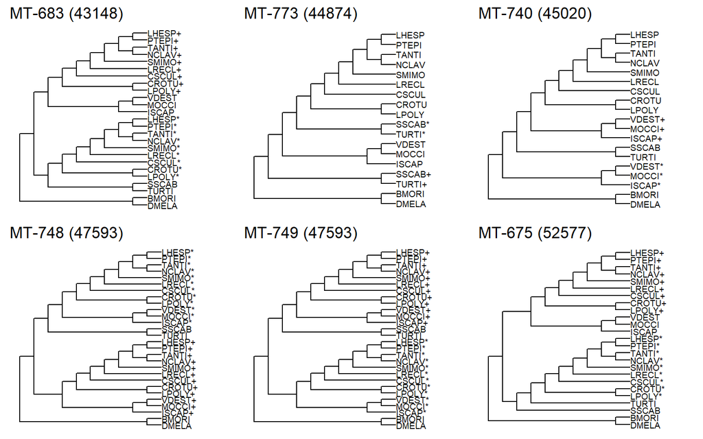

```r
cur_data_lowest = head(cur_data, 6)
# Get the lowest scoring trees

tree_fig_list = list()
# A list to store tree figures

for(i in 1:nrow(cur_data_lowest)){
  tree = read.tree(text=cur_data_lowest[i,]$Tree.string)
  # Read the current tree

  tree_fig = ggtree(tree, size=0.5, ladderize=T) +
  xlim(0, 14) +
    geom_tiplab(size=2.5) +
  ggtitle(paste(cur_data_lowest[i,]$Tree, " (", cur_data_lowest[i,]$Total.score, ")", sep=""))
  # Plot the current tree

  tree_fig_list[[i]] = tree_fig
  # Add the tree to the tree list
}

tree_figs = plot_grid(plotlist=tree_fig_list, ncol=3)
print(tree_figs)
```

```r
# Combine and render figs

cur_data_lowest$run = "Ballesteros R90 full"
combined_scores = rbind(combined_scores, cur_data_lowest)
```

# 4 Testing three species tree hypotheses

To understand the full history of gene and genome duplications it is important that we use the most accurate species tree. Here we test three alternate species tree hypotheses:

1. The traditional tree which places the horsehoe crabs outside of Arachnids (the monophyletic arachnid tree)
2. A more recent inference by Ballesteros et al. which indicates that horseshoe crabs may actually group within Arachnids, between Scorpiones (order) and Parasitiformes and Acariformes (superorders). See more notes here: https://gwct.github.io/spider-wgd/trees.html#notes-relating-to-ballesteros-et-al--2021
3. A species tree inferred from our data including paralogs with ASTRAL-pro, which also places horseshoe crabs within Arachnids, but swaps the positions of Acariformes and Parasitiformes.

Interestingly, with horseshoe crabs within Arachnids, the multiple rounds of WGD in these groups inferred on a monophyletic Arachnid tree may be a single event if they exist at all.

## 4.1 Comparing GRAMPA scores among species trees

We find that our tree and the Ballesteros tree score roughly equally (orange vs. dark blue lines) in a full GRAMPA search with the raw gene trees.

To increase confidence in our gene trees, we also performed bootstrap rearrangement with a threshold of 90 to minimize duplications and losses (see: https://www.cs.cmu.edu/~aiton/split/Manual-2.6.master008.html).

In all three cases, bootstrap rearrangement improves scores, and this widens the gap between our tree and the Ballesteros tree (dark red vs dark green lines).

Legend notes: ‘full’ indicates this was a full GRAMPA search with no H1 or H2 nodes. R90 runs with bootstrap rearrangment done on the gene trees.

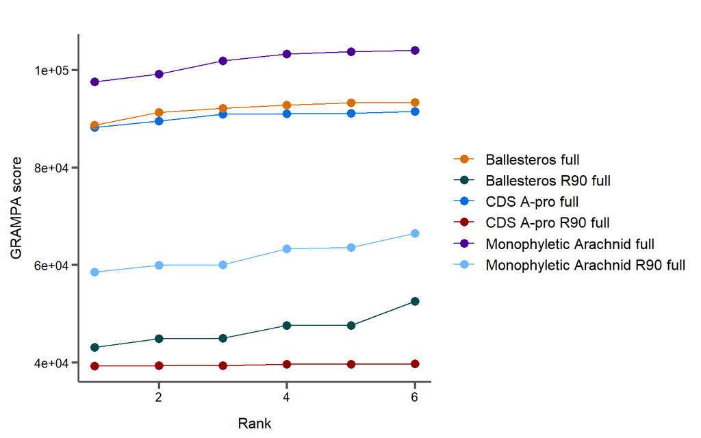

```r
scores_fig = ggplot(combined_scores, aes(x=rank, y=Total.score, color=run)) +
  geom_point(size=3) +
  geom_line() +
  scale_color_manual(values=corecol(numcol=9)) +
  xlab("Rank") +
  ylab("GRAMPA score") +
  bartheme()# +
  #theme(legend.position="bottom")
print(scores_fig)
```